# Tornadoes Hurt, Water Costs

Aneesh Sathe

June 12, 2015

# Synopsis:

Preventing fatalities, injuries and economic costs during severe weather is an important concern. Understanding the extent and type of damage any weather event causes would allow for appropriate planning and budgeting for such events. This analysis shows that Tornadoes cause the most fatalities. Economically, floods cause the most property damage, while drought severly affects crops. The weather event data used for analysis was sourced from the U.S. National Oceanic and Atmospheric Administration’s (NOAA) storm database and is available here: [Storm Data](https://d396qusza40orc.cloudfront.net/repdata%2Fdata%2FStormData.csv.bz2)

# Data Processing

The following libraries are used in the analysis and generation of plots

```r
library(data.table)
library(ggplot2)
library(gridExtra)
```

The data is read directly from the ZIP file.

```r
in_dat=data.table(read.table("repdata-data-StormData.csv.bz2",sep = ",",header = TRUE))
```

To access the relevant data we make a new data variable with just the required columns.

```r
pro_s_dat=in_dat[,c(8,23:28),with = FALSE]
```

The PROPDMGEXP and CROPDMGEXP columns represent the multiplicative factor for costs. Some of the data is missing or has letters representing hundreds, thousands, million billion etc. These are replaced with appropriate numbers for multiplication later.

```r
pro_s_dat[,PROPDMGEXP:= as.character(PROPDMGEXP)][PROPDMGEXP == "-"|PROPDMGEXP == ""|PROPDMGEXP == "?"|PROPDMGEXP == "+", PROPDMGEXP := "0"]
pro_s_dat[,PROPDMGEXP:= as.character(PROPDMGEXP)][PROPDMGEXP == "h"|PROPDMGEXP == "H", PROPDMGEXP := "2"]
pro_s_dat[,PROPDMGEXP:= as.character(PROPDMGEXP)][PROPDMGEXP == "m"|PROPDMGEXP == "M", PROPDMGEXP := "6"]
pro_s_dat[,PROPDMGEXP:= as.character(PROPDMGEXP)][PROPDMGEXP == "B", PROPDMGEXP := "9"]
pro_s_dat[,PROPDMGEXP:= as.character(PROPDMGEXP)][PROPDMGEXP == "K", PROPDMGEXP := "3"]



pro_s_dat[,CROPDMGEXP:= as.character(CROPDMGEXP)][CROPDMGEXP == "-"|CROPDMGEXP == ""|CROPDMGEXP == "?"|CROPDMGEXP == "+", CROPDMGEXP := "0"]
pro_s_dat[,CROPDMGEXP:= as.character(CROPDMGEXP)][CROPDMGEXP == "h"|CROPDMGEXP == "H", CROPDMGEXP := "2"]
pro_s_dat[,CROPDMGEXP:= as.character(CROPDMGEXP)][CROPDMGEXP == "m"|CROPDMGEXP == "M", CROPDMGEXP := "6"]
pro_s_dat[,CROPDMGEXP:= as.character(CROPDMGEXP)][CROPDMGEXP == "B", CROPDMGEXP := "9"]
pro_s_dat[,CROPDMGEXP:= as.character(CROPDMGEXP)][CROPDMGEXP == "K"|CROPDMGEXP == "k", CROPDMGEXP := "3"]
```

The property and crop costs are multiplied with the above generated columns to make new columns `CROP` and `PROP`. These are then added together to get the total damage column (`TOTDMG`). Similarly the total damage to the population is recorded in the `TOTPOP` column.

```r
s_dat=cbind(pro_s_dat[,1:3,with=F],data.frame(PROP=pro_s_dat$PROPDMG*10^as.numeric(pro_s_dat$PROPDMGEXP)),
            data.frame(CROP=(pro_s_dat$CROPDMG*10^as.numeric(pro_s_dat$CROPDMGEXP))))
s_dat=cbind(s_dat,data.frame(TOTDMG=s_dat$PROP+s_dat$CROP),data.frame(TOTPOP=s_dat$FATALITIES+s_dat$INJURIES))
```

In order to understand which of the weather events cause the most damage it is necessary to sum the damage and to sort the results in descending order. This is done below:

Population damage data calculation.

```r
f_dat=s_dat[,lapply(.SD,sum),by=EVTYPE,.SDcols=c("FATALITIES")]
f_dat=f_dat[order(-rank(FATALITIES))]
i_dat=s_dat[,lapply(.SD,sum),by=EVTYPE,.SDcols=c("INJURIES")]
i_dat=i_dat[order(-rank(INJURIES))]
h_dat=s_dat[,lapply(.SD,sum),by=EVTYPE,.SDcols=c("TOTPOP")]
h_dat=h_dat[order(-rank(TOTPOP))]
```

Property damage data calculation:

```r
p_dat=s_dat[,lapply(.SD,sum),by=EVTYPE,.SDcols=c("PROP")]
p_dat=p_dat[order(-rank(PROP))]
c_dat=s_dat[,lapply(.SD,sum),by=EVTYPE,.SDcols=c("CROP")]
c_dat=c_dat[order(-rank(CROP))]
e_dat=s_dat[,lapply(.SD,sum),by=EVTYPE,.SDcols=c("TOTDMG")]
e_dat=e_dat[order(-rank(TOTDMG))]
```

# Results

## Across the United States, which types of events (as indicated in the EVTYPE variable) are most harmful with respect to population health?

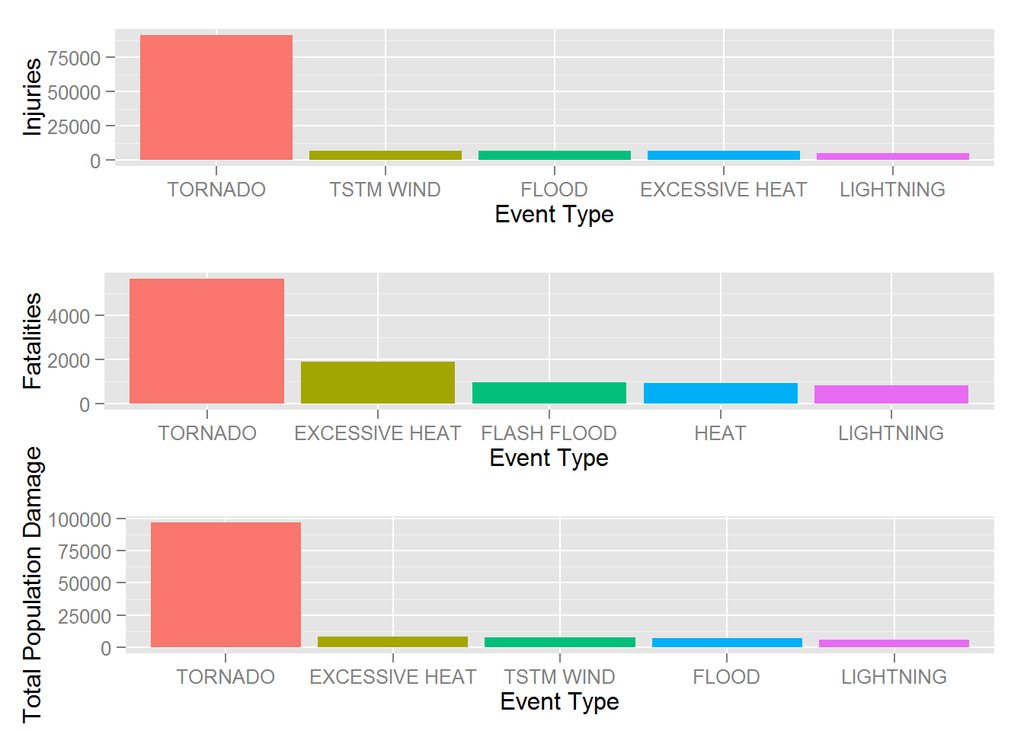

```r
p1=ggplot(h_dat[1:5,],aes(x=reorder(EVTYPE,-TOTPOP),y=TOTPOP,fill=reorder(EVTYPE,-TOTPOP)))+geom_bar(stat="identity")+xlab("Event Type")+ylab("Total Population Damage")+ theme(legend.position="none")
p2=ggplot(f_dat[1:5,],aes(x=reorder(EVTYPE,-FATALITIES),y=FATALITIES,fill=reorder(EVTYPE,-FATALITIES)))+geom_bar(stat="identity")+xlab("Event Type")+ylab("Fatalities")+ theme(legend.position="none")
p3=ggplot(i_dat[1:5,],aes(x=reorder(EVTYPE,-INJURIES),y=INJURIES,fill=reorder(EVTYPE,-INJURIES)))+geom_bar(stat="identity")+xlab("Event Type")+ylab("Injuries")+ theme(legend.position="none")
grid.arrange(p3,p2,p1)
```

The graph above shows that Tornadoes cause the most Fatalities and injuries. It is also notable that Excessive Heat causes a large amount of deaths as well was injuries.

## Across the United States, which types of events have the greatest economic consequences?

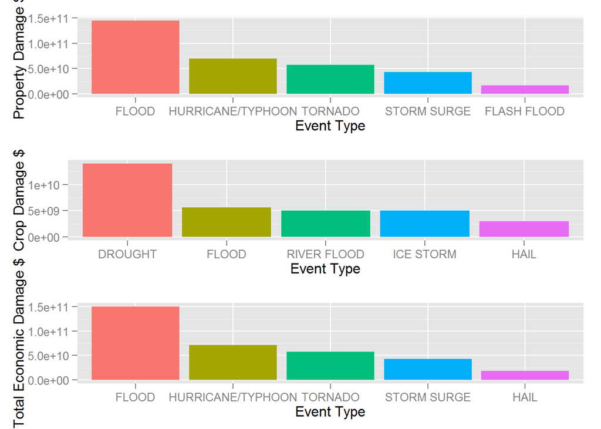

```r
p4=ggplot(e_dat[1:5,],aes(x=reorder(EVTYPE,-TOTDMG),y=TOTDMG,fill=reorder(EVTYPE,-TOTDMG)))+geom_bar(stat="identity")+xlab("Event Type")+ylab("Total Economic Damage $")+ theme(legend.position="none")
p5=ggplot(c_dat[1:5,],aes(x=reorder(EVTYPE,-CROP),y=CROP,fill=reorder(EVTYPE,-CROP)))+geom_bar(stat="identity")+xlab("Event Type")+ylab("Crop Damage $")+ theme(legend.position="none")
p6=ggplot(p_dat[1:5,],aes(x=reorder(EVTYPE,-PROP),y=PROP,fill=reorder(EVTYPE,-PROP)))+geom_bar(stat="identity")+xlab("Event Type")+ylab("Property Damage $")+ theme(legend.position="none")
grid.arrange(p6,p5,p4)
```

The most property damage is caused by floods while crops are severely affected by droughts and second most by floods. In terms of economic costs however floods cost the most followed by Hurricanes and Tornadoes.